# Evaluation-of-Various-Amazon-Recommendation-Systems

**Background**: Providing personalized recommendations relevant to individual users is the approach most likely to keep them engaged and increase business.

**Objective**: Extract meaningful insights from the data and build a recommendation system to provide customized product recommendations to customers based on their previous ratings for other products.

**Dataset**: This code uses a dataset that contains ratings of different electronic products from Amazon. It does not include information about the products or reviews to avoid bias while building the model. The following values are included in the dataset

- **userId:** Every user identified with a unique id
- **productId:** Every product identified with a unique id
- **Rating:** The rating of the corresponding product by the corresponding user
- **timestamp:** Time of the rating. We **will not use this column** to solve the current problem

Sometimes, the installation of the surprise library, which is used to build recommendation systems, faces issues in Jupyter. To avoid any issues, it is advised to use **Google Colab** for this project.

**Installing surprise library**

```python
!pip install surprise
```

```
     ━━━━━━━━━━━━━━━━━━━━━━━━━━━━━━━━━━━━━━━━ 772.0/772.0 kB 6.4 MB/s eta 0:00:00
  Preparing metadata (setup.py) ... done
```

## **Importing the necessary libraries**

```python
import warnings
warnings.filterwarnings("ignore")
import pandas as pd #data management
import numpy as np #data management
import matplotlib.pyplot as plt #data visualization
import seaborn as sns #data visualization
from collections import defaultdict             # A dictionary output that does not raise a key error
from collections import defaultdict             # A dictionary output that does not raise a key error
from sklearn.metrics import mean_squared_error  # A performance metrics in sklearn
```

### **Loading the data**

- Import the Dataset
- Add column names ['user_id', 'prod_id', 'rating', 'timestamp']
- Drop the column timestamp
- Copy the data to another DataFrame called **df**

```python
# Run this code to read the file from your device
from google.colab import files
uploaded = files.upload()# Read the  dataset file
data = pd.read_csv("ratings_Electronics.csv",header=None) #This dataset lacks any headers.
```

### Preliminary overview of the dataset

```python
data.shape
```

```
(7824482, 4)
```

```python
# View the first 5 rows of the dataset
data.head()
```

|  | 0 | 1 | 2 | 3 |
| --- | --- | --- | --- | --- |
| 0 | AKM1MP6P0OYPR | 0132793040 | 5.0 | 1365811200 |
| 1 | A2CX7LUOHB2NDG | 0321732944 | 5.0 | 1341100800 |
| 2 | A2NWSAGRHCP8N5 | 0439886341 | 1.0 | 1367193600 |
| 3 | A2WNBOD3WNDNKT | 0439886341 | 3.0 | 1374451200 |
| 4 | A1GI0U4ZRJA8WN | 0439886341 | 1.0 | 1334707200 |

```python
# The dataset does not have any headers so let's add
# Add column names
data.columns = ['user_id', 'prod_id', 'rating', 'timestamp']
```

```python
# Drop timestamps and copy it to a new DataFrame
data = data.drop('timestamp', axis = 1) # Dropping timestamp
df = data.copy(deep = True) # Copying the titled data to another DataFrame
```

```python
df.head()
```

|  | user_id | prod_id | rating |
| --- | --- | --- | --- |
| 0 | AKM1MP6P0OYPR | 0132793040 | 5.0 |
| 1 | A2CX7LUOHB2NDG | 0321732944 | 5.0 |
| 2 | A2NWSAGRHCP8N5 | 0439886341 | 1.0 |
| 3 | A2WNBOD3WNDNKT | 0439886341 | 3.0 |
| 4 | A1GI0U4ZRJA8WN | 0439886341 | 1.0 |

### Creating df_final by filtering the raw data based on criteria

**As this dataset is very large and has 7,824,482 observations, it is not computationally possible to build a model using this. Moreover, many users have only rated a few products and also some products are rated by very few users. Hence, we can reduce the dataset by considering certain logical assumptions.**

Let's truncate the dataset first by only taking users who have given at least 50 ratings then by selecting only products with at least 5 ratings, as when we shop online we prefer to have some number of ratings of a product.

```python
def Dataset_Truncator(df, CutoffCriteria, FeatureFilter):

  # Get the column containing the variable to filter the dataset by
  var = df.[FeatureFilter]

  # Create a dictionary from users to individual occurences of the target feature
  feature_count = dict()
  for count in var:

    # If the variable has been conted before, add 1 to their rating count
    if count in feature_count:
        feature_count[count] += 1

    # Otherwise, add it to the dict with a count of 1
    else:
        feature_count[count] = 1



  to_remove = []

  for count, num_ratings in feature_count.items():
    if num_ratings < CutoffCriteria:
      to_remove.append(count)

  df = df.loc[ ~ df.[FeatureFilter].isin(to_remove)]
```

```python
# We decided above to limit our model to users with at least 50 ratings
CutoffCriteria = 50
FeatureFilter = 'user_id'
Dataset_Truncator(df,CutoffCriteria,FeatureFilter)

# We decided above to limit our model to items with at least 5 ratings
CutoffCriteria = 5
FeatureFilter = 'prod_id'
Dataset_Truncator(df,CutoffCriteria,FeatureFilter)
```

```python
# Print a few rows of the imported dataset
df_final.head(10)
```

|  | user_id | prod_id | rating |
| --- | --- | --- | --- |
| 1310 | A3LDPF5FMB782Z | 1400501466 | 5.0 |
| 1322 | A1A5KUIIIHFF4U | 1400501466 | 1.0 |
| 1335 | A2XIOXRRYX0KZY | 1400501466 | 3.0 |
| 1451 | AW3LX47IHPFRL | 1400501466 | 5.0 |
| 1456 | A1E3OB6QMBKRYZ | 1400501466 | 1.0 |
| 1485 | A19N3S7CBSU6O7 | 1400501466 | 5.0 |
| 2082 | A2ZR3YTMEEIIZ4 | 1400532655 | 5.0 |
| 2150 | A3CLWR1UUZT6TG | 1400532655 | 5.0 |
| 2162 | A5JLAU2ARJ0BO | 1400532655 | 1.0 |
| 2228 | A1P4XD7IORSEFN | 1400532655 | 4.0 |

## **Exploratory Data Analysis**

### **Check the number of rows and columns and provide observations.**

```python
# Check the number of rows and columns and provide observations
df_final.shape
```

```
(65290, 3)
```

```python
data.shape
```

```
(7824482, 3)
```

```python
7824482-65290
```

```
7759192
```

- **The truncated dataset has 65290 rows and 3 columns.**
- **This is a reduction of 7759192 obsercations from the raw dataset.**

### **Data types and missing values**

```python
# Check Data types and missing values present and provide observations, then provide observations
df_final.info()
```

```
<class 'pandas.core.frame.DataFrame'>
Int64Index: 65290 entries, 1310 to 7824427
Data columns (total 3 columns):
 #   Column   Non-Null Count  Dtype
---  ------   --------------  -----
 0   user_id  65290 non-null  object
 1   prod_id  65290 non-null  object
 2   rating   65290 non-null  float64
dtypes: float64(1), object(2)
memory usage: 2.0+ MB
```

**Observations:**

- The variables user_id and prod_id of **object data type** and the rating is of **float data type**.
- The number of non-null values is the same as the total number of entries in the data, i.e., **there are no null values.**

### **Summary Statistics**

```python
# Summary statistics of 'rating' variable and provide observations
df_final['rating'].describe()
```

```
count    65290.000000
mean         4.294808
std          0.988915
min          1.000000
25%          4.000000
50%          5.000000
75%          5.000000
max          5.000000
Name: rating, dtype: float64
```

- **There are 65290 ratings, ranging from 1 to 5, with the 50th percentile being 5**
  - This suggests that the rating scale ranges from 1 to 5. Although some rating systems allow for a rating of 0, we would expect at least a single rating of 0 in our dataset if this rating system allowed for 0.
- **The average rating is 4.29 +- 0.99std.**

### **Checking the rating distribution**

#### Function to plot a boxplot and a histogram along the same scale

```python
# Function to plot a boxplot and a histogram along the same scale

#def histogram_boxplot(data, feature, figsize=None, kde=False, bins=None, binwidth=None, discrete=None):
def histogram_boxplot(data, feature, figsize=None, kde=False, bins=None, discrete=None, ystat='count'):
    """
    Boxplot and histogram combined

    data: dataframe
    feature: dataframe column
    figsize: size of figure (default (12,7))
    kde: whether to the show density curve (default False)
    bins: number of bins for histogram (default None)
    """

    print("")
    print("")
    print("")
    print()

    f2, (ax_box2, ax_hist2) = plt.subplots(
        nrows = 2,      # Number of rows of the subplot grid = 2
        sharex = True,  # x-axis will be shared among all subplots
        gridspec_kw = {"height_ratios": (0.25, 0.75)},
        figsize = figsize,
    )                   # Creating the 2 subplots
    sns.boxplot(data = data, x = feature, ax = ax_box2, showmeans = True, color = "violet"
    )                   # Boxplot will be created and a triangle will indicate the mean value of the column
    sns.histplot(
        data = data , x = feature, kde = kde, ax = ax_hist2, bins = bins, discrete=True, stat=ystat, palette = "winter"
    ) if bins else sns.histplot(
        data = data, x = feature, kde = kde, ax = ax_hist2, bins = bins, discrete=True, stat=ystat, palette = "winter"
    )                   # For histogram
    ax_hist2.axvline(
        data[feature].mean(), color = "green", linestyle = "--"
    )                   # Add mean to the histogram
    ax_hist2.axvline(
        data[feature].median(), color = "black", linestyle = "-"
    )                   # Add median to the histogram
    plt.tight_layout()
    plt.show()
    print("")
```

#### Combined boxplot and histogram of ratings

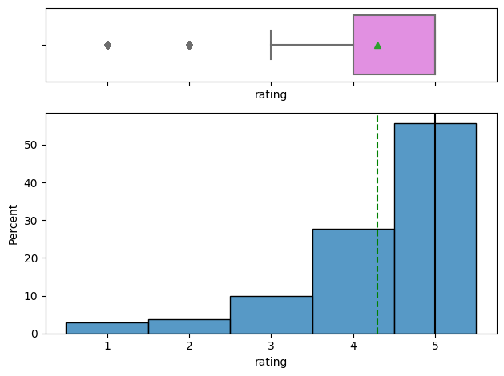

```python
histogram_boxplot(df_final, 'rating', figsize=None, kde=False, ystat='percent')
```

**Ratings are skewed left. More than 50% of ratings are 5**

### **Checking the number of unique users and items in the dataset**

```python
print('There are ', len(df_final), 'rows in the dataset.')
print('Of these, there are', df['user_id'].nunique(), 'unique users \n and',  df['prod_id'].nunique(), 'unique products.')
```

```
There are  65290 rows in the dataset.
Of these, there are 1540 unique users
 and 48190 unique products.
```

### **Users with the most number of ratings**

```python
 df_final['user_id'].value_counts().nlargest(10)
```

```
ADLVFFE4VBT8      295
A3OXHLG6DIBRW8    230
A1ODOGXEYECQQ8    217
A36K2N527TXXJN    212
A25C2M3QF9G7OQ    203
A680RUE1FDO8B     196
A1UQBFCERIP7VJ    193
A22CW0ZHY3NJH8    193
AWPODHOB4GFWL     184
AGVWTYW0ULXHT     179
Name: user_id, dtype: int64
```

- **The users who have provided the 10 most ratings range from 179 to 295.**

**Now that we have explored and prepared the data, let's build the first recommendation system.**

## **Model 1: Rank Based Recommendation System**

#### Creating a dataframe with average and total ratings for each product

```python
# Calculate the average rating for each product
RatingAvg = df_final.groupby('prod_id').mean()['rating']

# Calculate the count of ratings for each product
RatingCnt = df_final.groupby('prod_id').count()['rating']

# Create a dataframe with calculated average and count of ratings
Ratings_final = pd.DataFrame({'RatingAvg':RatingAvg, 'RatingCnt':RatingCnt})

# Sort the dataframe by average of ratings in the descending order
Ratings_final = Ratings_final.sort_values('RatingAvg', ascending=False)

# See the first five records of the "final_rating" dataset
Ratings_final.head()
```

| prod_id | RatingAvg | RatingCnt |
| --- | --- | --- |
| B00LGQ6HL8 | 5.0 | 5 |
| B003DZJQQI | 5.0 | 14 |
| B005FDXF2C | 5.0 | 7 |
| B00I6CVPVC | 5.0 | 7 |
| B00B9KOCYA | 5.0 | 8 |

#### Creating a function to recommend the highest rated n products with a minimum number of ratings

```python
# Defining a function to get the top n products based on the highest average rating and minimum interactions
def top_n_products(df, n, min_interaction):

    # Finding products with minimum number of interactions
    recommendations = df[df['RatingCnt'] >= min_interaction]

    # Sorting values with respect to average rating
    recommendations = recommendations.sort_values(by='RatingAvg', ascending=False)

    return print('The ', n, 'highest rated products with at least', min_interaction, 'ratings are', list(recommendations.index[:n]))
```

### **Recommending top 5 products with 50 minimum interactions based on popularity**

```python
top_n_products(Ratings_final, 5, 50)
```

```
The  5 highest rated products with at least 50 ratings are ['B001TH7GUU', 'B003ES5ZUU', 'B0019EHU8G', 'B006W8U2MU', 'B000QUUFRW']
```

### **Recommending top 5 products with 100 minimum interactions based on popularity**

```python
top_n_products(Ratings_final, 5, 100)
```

```
The  5 highest rated products with at least 100 ratings are ['B003ES5ZUU', 'B000N99BBC', 'B002WE6D44', 'B007WTAJTO', 'B002V88HFE']
```

We have recommended the **top 5** products by using the popularity recommendation system. Now, let's build a recommendation system using **collaborative filtering.**

## **Model 2: Collaborative Filtering Recommendation System**

### **Building a baseline user-user similarity based recommendation system**

- Below, we are building **similarity-based recommendation systems** using `cosine` similarity and using **KNN to find similar users** which are the nearest neighbor to the given user.
- We will be using a new library, called `surprise`, to build the remaining models. Let's first import the necessary classes and functions from this library.

```python
# To compute the accuracy of models
from surprise import accuracy

# Class is used to parse a file containing ratings, data should be in structure - user ; item ; rating
from surprise.reader import Reader

# Class for loading datasets
from surprise.dataset import Dataset

# For tuning model hyperparameters
from surprise.model_selection import GridSearchCV

# For splitting the rating data in train and test datasets
from surprise.model_selection import train_test_split

# For implementing similarity-based recommendation system
from surprise.prediction_algorithms.knns import KNNBasic

# For implementing matrix factorization based recommendation system
from surprise.prediction_algorithms.matrix_factorization import SVD

# for implementing K-Fold cross-validation
from surprise.model_selection import KFold

# For implementing clustering-based recommendation system
from surprise import CoClustering
```

**Before building the recommendation systems, let's go over some basic terminologies we are going to use:**

We want our recommendation system to maximize relevant suggestions.

A **relevant** item is one that's actually **rated higher than the threshold rating**.

An item will be considered **recommended** if its **predicted rating is higher than the threshold**.

We will focus our critique of model performance using Precision, Recall, and F1-score.

k = the number of recommendations to be provided to the user

**Precision@k** = the **fraction of recommended items that are relevant in `top k` predictions**.

**Recall@k** = the **fraction of relevant items that are recommended to the user in `top k` predictions**.

**F1-score@k** = the **harmonic mean of Precision@k and Recall@k**

### **Model Metric function**

- The function below provides the **precision@k, recall@k, and F1-score@k** for the **recommendation model**.

```python
def precision_recall_at_k(model, k = 10, threshold = 3.5):
    """Return precision and recall at k metrics for each user"""

    # First map the predictions to each user
    user_est_true = defaultdict(list)

    # Making predictions on the test data
    predictions = model.test(testset)

    for uid, _, true_r, est, _ in predictions:
        user_est_true[uid].append((est, true_r))

    precisions = dict()
    recalls = dict()
    for uid, user_ratings in user_est_true.items():

        # Sort user ratings by estimated value
        user_ratings.sort(key = lambda x: x[0], reverse = True)

        # Number of relevant items
        n_rel = sum((true_r >= threshold) for (_, true_r) in user_ratings)

        # Number of recommended items in top k
        n_rec_k = sum((est >= threshold) for (est, _) in user_ratings[:k])

        # Number of relevant and recommended items in top k
        n_rel_and_rec_k = sum(((true_r >= threshold) and (est >= threshold))
                              for (est, true_r) in user_ratings[:k])

        # Precision@K: Proportion of recommended items that are relevant
        precisions[uid] = n_rel_and_rec_k / n_rec_k if n_rec_k != 0 else 0

        # Recall@K: Proportion of relevant items that are recommended
       recalls[uid] = n_rel_and_rec_k / n_rel if n_rel != 0 else 0

    # Mean of all the predicted precisions are calculated.
    precision = round((sum(prec for prec in precisions.values()) / len(precisions)), 3)

    # Mean of all the predicted recalls are calculated.
    recall = round((sum(rec for rec in recalls.values()) / len(recalls)), 3)

    accuracy.rmse(predictions)

    print('Precision: ', precision) # print precision metric

    print('Recall: ', recall) # print recall metric

    print('F_1 score: ', round((2*precision*recall)/(precision+recall), 3)) # Compute and pring F-1 score metric
```

We must load the DataFrame sf into a different format called **`surprise.dataset.DatasetAutoFolds`** in order to use the surprise library.

```python
# Instantiating Reader scale with expected rating scale
reader = Reader(rating_scale=(1, 5))

# Loading the rating dataset
data = Dataset.load_from_df(df_final[['user_id', 'prod_id', 'rating']], reader)

# Splitting the data into train and test datasets
trainset, testset = train_test_split(data, test_size=0.20, random_state=1)
```

Let's first build a baseline similarity-based recommendation system using the cosine similarity.

### **Building the user-user Similarity-based Recommendation System**

```python
# Declaring the similarity options
sim_options = {'name': 'cosine',
               'user_based': True}

# Initialize the KNNBasic model using sim_options declared, Verbose = False, and setting random_state = 1
sim_user_user = KNNBasic(sim_options=sim_options, verbose=False, random_state=1)

# Fit the model on the training data
sim_user_user.fit(trainset)

# Let us compute precision@k, recall@k, and f_1 score using the precision_recall_at_k function defined above
precision_recall_at_k(sim_user_user)
```

```
RMSE: 1.0260
Precision:  0.844
Recall:  0.862
F_1 score:  0.853
```

- **We calculated RSME to check deviation of predicted relevant products from actually relevant products**
- Our **recall of 0.862** means that **86.2% of relevant products are actually recommended to the user**.
- The **precision of 0.844** means that **84.4% of recommended products are actually relevant to the user.**
- The combined performance of recall and precision is reflected by the **F1 score of 0.853**.

Let's now **predict rating for a user with `userId=A3LDPF5FMB782Z` and `productId=1400501466`** as shown below. Here the user has already interacted or watched the product with productId '1400501466' and given a rating of 5.

```python
# Predicting rating for a sample user with an interacted product
sim_user_user.predict("A3LDPF5FMB782Z", "1400501466", r_ui = 5, verbose = True)
```

```
user: A3LDPF5FMB782Z item: 1400501466 r_ui = 5.00   est = 3.33   {'actual_k': 6, 'was_impossible': False}
```

```
Prediction(uid='A3LDPF5FMB782Z', iid='1400501466', r_ui=5, est=3.3333333333333335, details={'actual_k': 6, 'was_impossible': False})
```

- **This user gave this product an actual rating of 5, but the model predicted they wourld rate it at 3.33**.
- Thus, the model underestimates the user's rating in this instance.

Below is the **list of users who have not seen the product with product id "1400501466"**.

```python
# Find unique user_id where prod_id is not equal to "1400501466"
NoInteraction=df_final[df_final.prod_id != "1400501466"].user_id.unique()
list(NoInteraction)[:10]
```

```
['A2ZR3YTMEEIIZ4',
 'A3CLWR1UUZT6TG',
 'A5JLAU2ARJ0BO',
 'A1P4XD7IORSEFN',
 'A341HCMGNZCBIT',
 'A3HPCRD9RX351S',
 'A1DQHS7MOVYYYA',
 'ALUNVOQRXOZIA',
 'A19N3S7CBSU6O7',
 'A3G7BEJJCPD6DS']
```

- It can be observed from the above list that **user "A2ZR3YTMEEIIZ4" has not seen the product with productId "1400501466"** as this userId is a part of the above list.
  - **PLEASE NOTE THAT THE ABOVE STATMENT WAS IN THE DEFAULT NOTEBOOK AND WAS NOT REPLICATED IN THIS PROJECT. I PROCEEDED AS IF THAT USER HAD INDEED APPEARED IN THE ABOVE LIST.**

**Below we are predicting rating for `userId=A2ZR3YTMEEIIZ4` and `prod_id=1400501466`.**

```python
# Predicting rating for a sample user with a non interacted product
sim_user_user.predict("A2ZR3YTMEEIIZ4", "1400501466", verbose = True)
```

[output not shown]

[output not shown]

- **This user is predicted to give the product a rating of 1.99**

### **Improving similarity-based recommendation system by tuning its hyperparameters**

```python
# Setting up parameter grid to tune the hyperparameters
param_grid = {'k': [10, 20, 30, 40, 50], 'min_k': [1, 3, 6, 9],
              'sim_options': {'name': ['cosine','pearson','msd','pearson_baseline'],
                              'user_based': [True], 'min_support': [2, 4, 6]}
              }

# Performing 3-fold cross-validation to tune the hyperparameters
gs = GridSearchCV(KNNBasic, param_grid, measures=['rmse'], cv=3, n_jobs=-1)

# Fitting the data
gs.fit(data)

# Best RMSE score
print('Optimized rsme = ', gs.best_score['rmse'])

# Combination of parameters that gave the best RMSE score
print('Optimal parameters are ', gs.best_params['rmse'])
```

```
Optimized rsme =  0.9803267520037484
Optimal parameters are  {'k': 30, 'min_k': 3, 'sim_options': {'name': 'cosine', 'user_based': True, 'min_support': 2}}
```

Now, let's build the **final model by using** optimal values for each of those hyperparameters**, which we received by using** grid search cross-validation**.

```python
# Using the optimal similarity measure for user-user based collaborative filtering
sim_options_optimized = {'name': 'cosine',
               'user_based': True}

# Creating an instance of KNNBasic with optimal hyperparameter values
sim_user_user_optimized = KNNBasic(sim_options_optimized=sim_options_optimized, k=30, min_k=3, min_support=2, random_state=1, verbose=True)

# Training the algorithm on the trainset
sim_user_user_optimized.fit(trainset)

# Let us compute precision@k and recall@k also with k =10
precision_recall_at_k(sim_user_user_optimized)
```

```
Computing the msd similarity matrix...
Done computing similarity matrix.
RMSE: 0.9848
Precision:  0.841
Recall:  0.884
F_1 score:  0.862
```

### **Steps:**

```python
# Use sim_user_user_optimized model to recommend for userId "A3LDPF5FMB782Z" and productId 1400501466
sim_user_user_optimized.predict("A3LDPF5FMB782Z", "1400501466", r_ui = 5, verbose = True)
```

```
user: A3LDPF5FMB782Z item: 1400501466 r_ui = 5.00   est = 4.74   {'actual_k': 6, 'was_impossible': False}
```

```
Prediction(uid='A3LDPF5FMB782Z', iid='1400501466', r_ui=5, est=4.73758865248227, details={'actual_k': 6, 'was_impossible': False})
```

```python
# Use sim_user_user_optimized model to recommend for userId "A34BZM6S9L7QI4" and productId "1400501466"
sim_user_user_optimized.predict("A2ZR3YTMEEIIZ4", "1400501466", verbose = True)
```

[output not shown]

[output not shown]

**The optimized user_user model is much more accurate in predicting the rating of a customer who has actually rated the product than the original, default model,**

- original model's error = -1.67
- opimized model's error = -0.26

**The optimized model also predicts that the user who hasn't interacted with the product will rate it much higher than the default model predicted (4.3 vs 1.99)**

### **Identifying similar users to a given user (nearest neighbors)**

We can also find out **similar users to a given user** or its **nearest neighbors** based on this KNNBasic algorithm. Below, we are finding the 5 most similar users to the first user in the list with internal id 0, based on the `msd` distance metric.

```python
# 0 is the inner id of the above user
sim_user_user_optimized.get_neighbors(0,k=5)
```

```
[1, 17, 28, 30, 35]
```

### **Implementing the recommendation algorithm based on optimized KNNBasic model**

Below we will be implementing a function where the input parameters are:

- data: A **rating** dataset
- user_id: A user id **against which we want the recommendations**
- top_n: The **number of products we want to recommend**
- algo: the algorithm we want to use **for predicting the ratings**
- The output of the function is a **set of top_n items** recommended for the given user_id based on the given algorithm

```python
def get_recommendations(data, user_id, top_n, algo):

    # Creating an empty list to store the recommended product ids
    recommendations = []

    # Creating an user item interactions matrix
    user_item_interactions_matrix = data.pivot(index = 'user_id', columns = 'prod_id', values = 'rating')

    # Extracting those product ids which the user_id has not interacted yet
    non_interacted_products = user_item_interactions_matrix.loc[user_id][user_item_interactions_matrix.loc[user_id].isnull()].index.tolist()

    # Looping through each of the product ids which user_id has not interacted yet
    for item_id in non_interacted_products:

        # Predicting the ratings for those non interacted product ids by this user
        est = algo.predict(user_id, item_id).est

        # Appending the predicted ratings as a tuple
        recommendations.append((item_id, est))

    # Sorting the predicted ratings in descending order
    recommendations.sort(key = lambda x: x[1], reverse = True)
    print('The top', top_n, 'products recommended for user', user_id, 'are \n', recommendations[:top_n])

    return recommendations[:top_n] # Returing top n highest predicted rating products for this user
```

**Predicting top 5 products for userId = "A3LDPF5FMB782Z" with similarity based recommendation system**

```python
# Making top 5 recommendations for user_id "A3LDPF5FMB782Z" with a similarity-based recommendation engine
user_user_recommendations_optimized = get_recommendations(df_final, "A3LDPF5FMB782Z", 5, sim_user_user_optimized)
```

```
The top 5 products recommended for user A3LDPF5FMB782Z are
 [('B00004WCGF', 5), ('B00005LEN4', 5), ('B00005U21H', 5), ('B000067RT6', 5), ('B00006B7DA', 5)]
```

```python
# Building the dataframe for above recommendations with columns "prod_id" and "predicted_ratings"
RecProducts = pd.DataFrame(user_user_recommendations_optimized, columns=['prod_id', 'predicted_ratings'])
RecProducts
```

|  | prod_id | predicted_ratings |
| --- | --- | --- |
| 0 | B00004WCGF | 5 |
| 1 | B00005LEN4 | 5 |
| 2 | B00005U21H | 5 |
| 3 | B000067RT6 | 5 |
| 4 | B00006B7DA | 5 |

### **Item-Item Similarity-based Collaborative Filtering Recommendation System**

- Above we used **similarity-based collaborative filtering**, i.e., calculated similarity **between users**. Let's try calculating similarity **between items**.

```python
# Declaring the similarity options
sim_options = {'name': 'cosine',
               'user_based': False}


# KNN algorithm is used to find desired similar items. Use random_state=1
sim_item_item = KNNBasic(sim_options = sim_options, random_state = 1, verbose = False)

# Train the algorithm on the trainset, and predict ratings for the test set
sim_item_item.fit(trainset)

# Let us compute precision@k, recall@k, and f_1 score with k = 10
precision_recall_at_k(sim_item_item)
```

```
RMSE: 1.0147
Precision:  0.826
Recall:  0.853
F_1 score:  0.839
```

- **We calculated RSME to check deviation of predicted relevant products from actually relevant products**
- Our **recall of 0.853** means that **85.3% of relevant products are actually recommended to the user**.
- The **precision of 0.826** means that **82.6% of recommended products are actually relevant to the user.**
- The combined performance of recall and precision is reflected by the **F1 score of 0.839**.

Let's now **predict a rating for a user with `userId = A3LDPF5FMB782Z` and `prod_Id = 1400501466`** as shown below. Here the user has already interacted or watched the product with productId "1400501466".

```python
# Predicting rating for a sample user with an interacted product
sim_item_item.predict("A3LDPF5FMB782Z", "1400501466", r_ui=5, verbose=True)
```

```
user: A3LDPF5FMB782Z item: 1400501466 r_ui = 5.00   est = 4.30   {'actual_k': 20, 'was_impossible': False}
```

```
Prediction(uid='A3LDPF5FMB782Z', iid='1400501466', r_ui=5, est=4.3, details={'actual_k': 20, 'was_impossible': False})
```

- **This user gave this product an actual rating of 5, but the model predicted they wourld rate it at 4.3**.
- While the default item-item model still underestimates the user's rating, it does so less than the default user-user model.

```python
# Predicting rating for a sample user with a non interacted product
sim_item_item.predict("A2ZR3YTMEEIIZ4", "1400501466",verbose=True)
```

[output not shown]

[output not shown]

**The default item-item model predicts this user will rate the product at 4.0.**

### **Hyperparameter tuning the item-item similarity-based model**

```python
# Setting up parameter grid to tune the hyperparameters
param_grid = {'k': [10, 20, 30], 'min_k': [3, 6, 9],
              'sim_options': {'name': ['msd','cosine'],
                              'user_based': [False]}
              }

# Performing 3-fold cross validation to tune the hyperparameters
gs = GridSearchCV(KNNBasic, param_grid, measures=['rmse'], cv=3, n_jobs=-1)

# Fitting the data
gs.fit(data)

# Find the best RMSE score
print(gs.best_score['rmse'])

# Find the combination of parameters that gave the best RMSE score
print(gs.best_params['rmse'])
```

```
0.9736774134174668
{'k': 30, 'min_k': 6, 'sim_options': {'name': 'msd', 'user_based': False}}
```

### **Use the best parameters from GridSearchCV to build the optimized item-item similarity-based model. Compare the performance of the optimized model with the baseline model.**

Now let's build the **final model** by using **tuned values of the hyperparameters** which we received by using grid search cross-validation.

```python
# Using the optimal similarity measure for item-item based collaborative filtering
sim_options_optimized = {'name': 'msd',
               'user_based': False}

# Creating an instance of KNNBasic with optimal hyperparameter values
sim_item_item_optimized = KNNBasic(sim_options_optimized = sim_options_optimized, k=30, min_k = 6, random_state = 1, verbose = False)

# Training the algorithm on the trainset
sim_item_item_optimized.fit(trainset)

# Let us compute precision@k and recall@k, f1_score and RMSE
precision_recall_at_k(sim_item_item_optimized)
```

```
RMSE: 0.9771
Precision:  0.834
Recall:  0.896
F_1 score:  0.864
```

### **Steps:**

- **Predict rating for the user with `userId="A3LDPF5FMB782Z"`, and `prod_id= "1400501466"` using the optimized model**
- **Predict rating for `userId="A2ZR3YTMEEIIZ4"` who has not interacted with `prod_id ="1400501466"`, by using the optimized model**
- **Compare the output with the output from the baseline model**

```python
# Use sim_item_item_optimized model to recommend for userId "A3LDPF5FMB782Z" and productId "1400501466"
sim_item_item_optimized.predict("A3LDPF5FMB782Z", "1400501466", r_ui =  5, verbose=True)
```

```
user: A3LDPF5FMB782Z item: 1400501466 r_ui = 5.00   est = 4.74   {'actual_k': 6, 'was_impossible': False}
```

```
Prediction(uid='A3LDPF5FMB782Z', iid='1400501466', r_ui=5, est=4.73758865248227, details={'actual_k': 6, 'was_impossible': False})
```

```python
# Use sim_item_item_optimized model to recommend for userId "A34BZM6S9L7QI4" and productId "1400501466"
sim_item_item_optimized.predict("A2ZR3YTMEEIIZ4", "1400501466", verbose=True)
```

[output not shown]

[output not shown]

**The optimized item-item model is slightly more accurate in predicting the rating of a customer who has actually rated the product than the original, default model.**

- default item-item model's error = -0.7
- opimized item-item model's error = -0.26

**The optimized item-item model also predicts that the user who hasn't interacted with the product will rate it slightly higher than the default item-item model predicted (4.3 vs 4.0).**

Interestingly, the **optimized item-item model predicts the same ratings as the optimized user-user model** in these cases.

### **Identifying similar items to a given item (nearest neighbors)**

We can also find out **similar items** to a given item or its nearest neighbors based on this **KNNBasic algorithm**. Below we are finding the 5 most similar items to the item with internal id 0 based on the `msd` distance metric.

```python
sim_item_item_optimized.get_neighbors(0,k=5)
```

[output not shown]

**Hint:** Use the get_recommendations() function.

```python
# Making top 5 recommendations for user_id A1A5KUIIIHFF4U with similarity-based recommendation engine.
item_item_recommendations_optimized = get_recommendations(df_final, "A3LDPF5FMB782Z", 5, sim_item_item_optimized)
```

```
The top 5 products recommended for user A3LDPF5FMB782Z are
 [('B000067RT6', 5), ('B001TH7GUU', 5), ('B001UI2FPE', 5), ('B001V9KG0I', 5), ('B00316263Y', 5)]
```

```python
# Building the dataframe for above recommendations with columns "prod_id" and "predicted_ratings"

RecProducts = pd.DataFrame(item_item_recommendations_optimized, columns=['prod_id', 'predicted_ratings'])
RecProducts
```

|  | prod_id | predicted_ratings |
| --- | --- | --- |
| 0 | B000067RT6 | 5 |
| 1 | B001TH7GUU | 5 |
| 2 | B001UI2FPE | 5 |
| 3 | B001V9KG0I | 5 |
| 4 | B00316263Y | 5 |

### **Model 3: Model-Based Collaborative Filtering - Matrix Factorization**

Last, let's test model-based Collaborative Filtering, which is based on the past behavior of the user and it is not dependent on any additional information. We use **latent features** to find recommendations for each user.

### Singular Value Decomposition (SVD)

SVD is used to **compute the latent features** from the **user-item matrix**. But SVD does not work when we **miss values** in the **user-item matrix**.

```python
# Using SVD matrix factorization. Use random_state = 1
svd = SVD(random_state=1)

# Training the algorithm on the trainset
svd.fit(trainset)

# Use the function precision_recall_at_k to compute precision@k, recall@k, F1-Score, and RMSE
precision_recall_at_k(svd)
```

```
RMSE: 0.9104
Precision:  0.837
Recall:  0.88
F_1 score:  0.858
```

- **We calculated RSME to check deviation of predicted relevant products from actually relevant products**
- Our **recall of 0.88** means that **88% of relevant products are actually recommended to the user**.
- The **precision of 0.837** means that **83.7% of recommended products are actually relevant to the user.**
- The combined performance of recall and precision is reflected by the **F1 score of 0.858**.

**Let's now predict the rating for a user with `userId = "A3LDPF5FMB782Z"` and `prod_id = "1400501466`.**

```python
# Making prediction
svd.predict("A3LDPF5FMB782Z", "1400501466", r_ui=5, verbose=True)
```

```
user: A3LDPF5FMB782Z item: 1400501466 r_ui = 5.00   est = 4.09   {'was_impossible': False}
```

```
Prediction(uid='A3LDPF5FMB782Z', iid='1400501466', r_ui=5, est=4.094312160755627, details={'was_impossible': False})
```

- **This user gave this product an actual rating of 5, but the model predicted they wourld rate it at 4.09**.
- Thus, this model also underestimates the user's rating.

```python
# Making prediction
svd.predict("A2ZR3YTMEEIIZ4", "1400501466", verbose=True)
```

[output not shown]

[output not shown]

**The default matrix factorization model predicts this user will rate the product at 4.05.**

### **Improving Matrix Factorization based recommendation system by tuning its hyperparameters**

Below we will be tuning only three hyperparameters:

- **n_epochs**: The number of iterations of the SGD algorithm.
- **lr_all**: The learning rate for all parameters.
- **reg_all**: The regularization term for all parameters.

```python
# Set the parameter space to tune
param_grid = {'n_epochs': [10, 20, 30], 'lr_all': [0.001, 0.005, 0.01],
              'reg_all': [0.2, 0.4, 0.6]}

# Performing 3-fold gridsearch cross-validation
gs_ = GridSearchCV(SVD, param_grid, measures=['rmse'], cv=3, n_jobs=-1)

# Fitting data
gs_.fit(data)

# Best RMSE score
print(gs_.best_score['rmse'])

# Combination of parameters that gave the best RMSE score
print(gs_.best_params['rmse'])
```

```
0.8980976344770273
{'n_epochs': 20, 'lr_all': 0.01, 'reg_all': 0.2}
```

Now, we will **the build final model** by using **tuned values** of the hyperparameters, which we received using grid search cross-validation above.

```python
# Build the optimized SVD model using optimal hyperparameter search. Use random_state=1
svd_optimized = SVD(n_epochs=20, lr_all=0.01, reg_all=0.2, random_state=1)

# Train the algorithm on the trainset
svd_optimized=svd_optimized.fit(trainset)

# Use the function precision_recall_at_k to compute precision@k, recall@k, F1-Score, and RMSE
precision_recall_at_k(svd_optimized)
```

```
RMSE: 0.9014
Precision:  0.841
Recall:  0.88
F_1 score:  0.86
```

### **Steps:**

- **Predict rating for the user with `userId="A3LDPF5FMB782Z"`, and `prod_id= "1400501466"` using the optimized model**
- **Predict rating for `userId="A2ZR3YTMEEIIZ4"` who has not interacted with `prod_id ="1400501466"`, by using the optimized model**
- **Compare the output with the output from the baseline model**

```python
# Use svd_algo_optimized model to recommend for userId "A3LDPF5FMB782Z" and productId "1400501466"
svd_optimized.predict("A3LDPF5FMB782Z", "1400501466", r_ui=5, verbose=True)
```

```
user: A3LDPF5FMB782Z item: 1400501466 r_ui = 5.00   est = 4.09   {'was_impossible': False}
```

```
Prediction(uid='A3LDPF5FMB782Z', iid='1400501466', r_ui=5, est=4.090441179731308, details={'was_impossible': False})
```

```python
# Use svd_algo_optimized model to recommend for userId "A34BZM6S9L7QI4" and productId "1400501466"
svd_optimized.predict("A2ZR3YTMEEIIZ4", "1400501466", verbose=True)
```

[output not shown]

[output not shown]

**The optimized svd model predicts the same rating as the default model for a customer who has actually rated the product.**

**The optimized svd model predicts almost the same rating for the user who hasn't interacted with the product will rate it slightly higher than the default item-item model predicted** (4.05 default vs 4.06 optimized).

### **Conclusion and Recommendations**

- Here, we developed 4 recommendation models: rank-based, user-user similarity-based, item-item similarity-based, and matrix factorization-based.
  - The latter 3 algorithms utilize collaborative filtering
- Hyperparameters for collaborative filtering models were tuned with grid search cross-validation to improve performance.
- Model performance was evaluated using precision@k and recall@k.
- Precision is potentially the most important factor since **we want to minimize the number of not relevant products we recommen to users.**
  - While the optimized item-item similarity-based recommendation system had the highest F1 score (0.864), it's precision was the second worst (0,834).
- **The default user-user model has the best precision (0.844).**
  - However, this was only slightly better than precision of the optimized user-user and optimized matrix factorization models (both 0.841).
- The optimized matrix factorization model had the lowest RMSE (0.9014), implying better handling of latent factors in the dataset.
- While the optimized user-user model had slightly worse precision, it had much greater recall than the deafault user-user modle. Although precision is our primary metric of interest, it is also important that we are recommending as many relevant products as there are (i.e., recall).

-Therefore, we would suggest that user recommendations should be produced using a hybrid recommendation system that incorporates both the optimized matrix factorization model and optimized user-user models.